# Trabalho 02

.

# Séries Temporais

#### Igor Kuivjogi / Kaíque Ferreira / Nilo Célio

#### **2° Trabalho de Séries Temporais**

##### 28 de Julho de 2020

.

## Série PFI

### Caracteristicas da série

- Produção física industrial total mensal
- Data: Mês de janeiro de 1991 a dezembro de 1999
- Foi desconsiderado os valores de janeiro de 2000 a julho de 2000

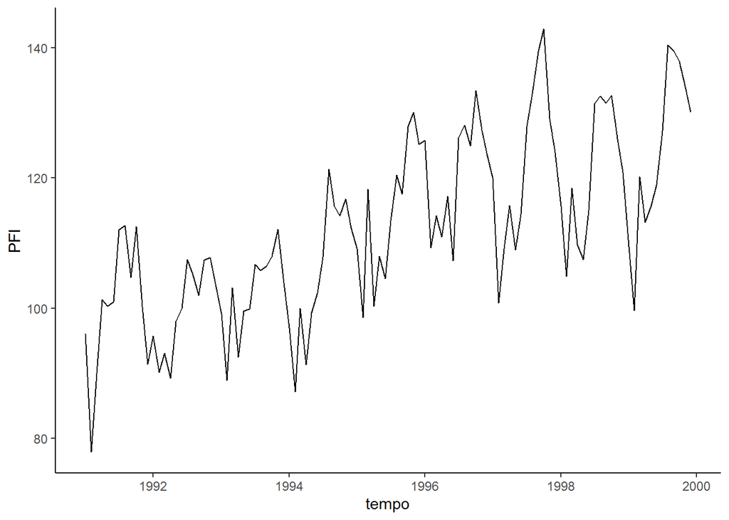

### Subsérie PFI

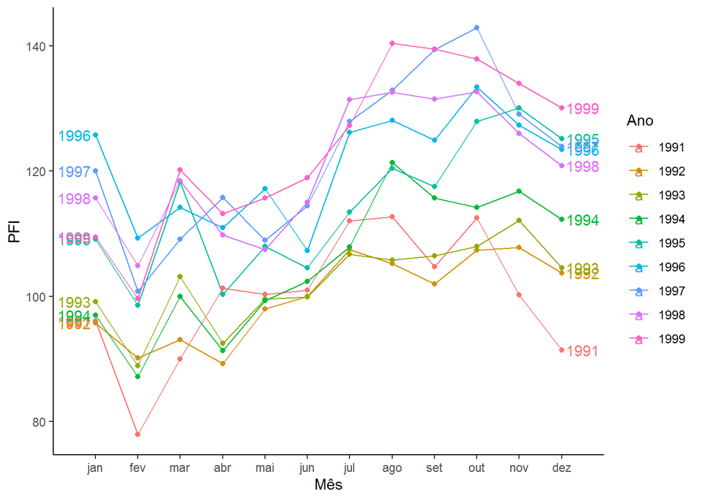

## Decomposição STL

### Parâmetros da decomposição STL

- Np é número de observações que compõem o período
- Ns seria o parâmetro de suavização para o componente sazonal. De acordo com Cleveland et al. 1990, esse valor deve ser ímpar e maior ou igual a 7 e não tem default.

```r
nt = function(Np,Ns) (1.5 * Np)/(1 - 1.5/Ns)

nt(12,13)
```

```
## [1] 20.34783
```

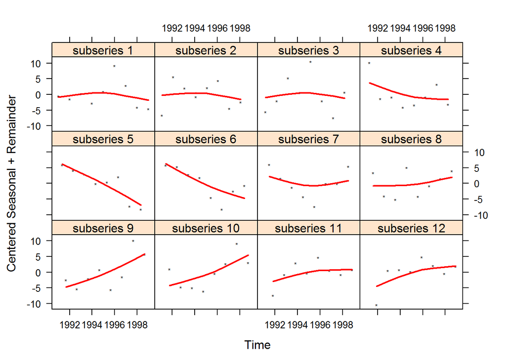

```r
Dados_PFI$PFI %>%
  ts( start = 1991, end = 1999, frequency = 12) %>%
  stlplus( n.p = 12, t.window = 21, s.window = 13 ) %>%
  plot_seasonal( col = c("black", "red"), lwd = 2, pch = "*")
```

### Tendência e Sazonalidade

- inner, o número de loop internos que o algoritmo deve executar, normalmente utiliza-se um número baixo, por exemplo, 2. O loop interno é usado para obter estimativas dos componentes de tendência e sazonalidade.
- outer, o número de loop externos que o algoritmo deve executar, ou seja, o número de interações de robustes do loop externo. Ajusta a ponderação para os pontos outlier.
- l.window, a extensão (em defasagens) da janela loess do filtro passa-baixo usado para cada sub-série. Deve ser ímpar e tem default.
- t.window, é o parâmetro de suavização para o componente de tendência; deve ser um valor ímpar e tem default.
- s.window, seria o parâmetro de suavização para o componente sazonal. De acordo com Cleveland et al. 1990, esse valor deve ser ímpar e maior ou igual a 7 e não tem default.

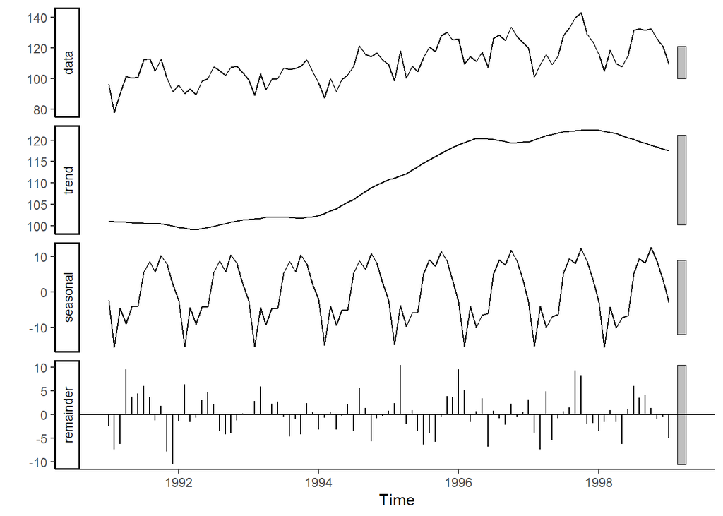

```r
Dados_PFI$PFI %>%
  ts( start = 1991, end = 1999, frequency = 12) %>%
  stl(inner = 1, outer = 0, robust = FALSE,
      l.window = 13, t.window = 21, s.window = 13 ) %>%
  autoplot()
```

## Modelo Holt Winters

### Escolha dos parâmetros

```r
# Série sem o ano de 1999
serie = ts(Dados_PFI$PFI, start = c(1991, 1), end = c(1998, 12), frequency = 12)

# Grid com parâmetros
grid = expand_grid(
  alpha    = seq(0.1, 1, 0.1),
  beta     = seq(0.1, 1, 0.1),
  gamma    = seq(0.1, 1, 0.1),
  seasonal = c('additive', 'multiplicative')
)

# Funcao para Holt Winters
funcao = function(um, dois, tres, quatro, ...) {
  modelo = HoltWinters(serie, alpha = um, beta = dois,
                       gamma = tres, seasonal = quatro)

  return(modelo)
}

# loop do modelo em cada combinação de parâmetro
modelos = list(grid$alpha, grid$beta, grid$gamma, grid$seasonal) %>%
            pmap(funcao)
```

### Previsão

```r
# Previsão da série ajustada
serie_ajustada = function(modelo) {

  df_ajuste = tibble(
       tempo = c(Dados_PFI[1:108, ]$tempo, Dados_PFI[13:96, ]$tempo, Dados_PFI[97:108, ]$tempo),
       dados = c(
           Dados_PFI$PFI,
           c(fitted(modelo)[ ,1]),
           predict(modelo, 12, prediction.interval=TRUE)[ ,1]
        ),
        legenda = c(rep('dados obs', 108),
                  rep('Holt Winters (ajuste)', 84),
                  rep('Holt Winters (previsão)', 12))
  )

  eqm = mean((df_ajuste[97:108, ]$dados - df_ajuste[193:204, ]$dados) ^ 2)

  return(eqm)

}

# Lista dos EMQ
lista_eqms = map_dbl(modelos, ~serie_ajustada(.x))

# Menor EQM
menor_eqm = which.min(lista_eqms)

# Modelo com os melhorores parâmetros
best_ht = HoltWinters(serie,
                       alpha    = grid[menor_eqm, ]$alpha,
                       beta     = grid[menor_eqm, ]$beta,
                       gamma    = grid[menor_eqm, ]$gamma,
                       seasonal = grid[menor_eqm, ]$seasonal)
```

### Gŕafico do melhor modelo

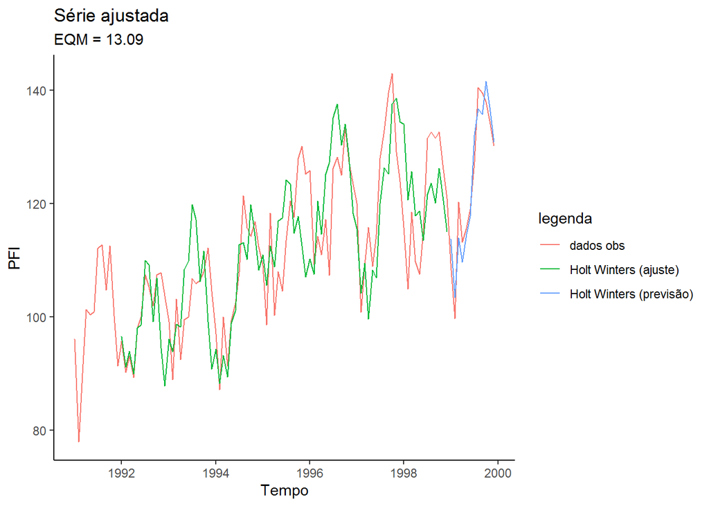